# Process Mining with Jupyter Notebook and Disco

## Disco

Process Mining software Disco was developed from scratch with the goal to make Process Mining accessible for business users. Disco’s framework is based on proven scientific research and it has been in use in various industries with use cases like customer journey analysis, audit, process improvement and optimization. The tool allows an easy and flexible discovery of processes with its visualization and filtering capabilities. Fluxicon also organizes the annual Process Mining Camp, has written the “Process Mining in Practice” book that defines the process mining methodology for practitioners, and supports close to 700 universities through the Fluxicon Academic Initiative.

Link : https://www.processmining-software.com/tools/disco/

#### Dataset

The data recorded for the execution of Purchase-To-Pay processes.

It recorded possibly from an ERP system.

link : https://icpmconference.org/2019/icpm-2019/contests-challenges/bpi-challenge-2019/

### Disco recognized column setup

- Unique case ID column
- Time stamp column
- User column
- Activity column
- Other column

### Import library

```python
import unicodedata
import pandas as pd
import numpy as np
import seaborn as sns
import matplotlib.pyplot as plt
%matplotlib inline
import string
```

```python
df = pd.read_csv("BPI2019.csv", encoding='cp1252')
df.head()
```

|  | eventID | case Spend area text | case Company | case Document Type | case Sub spend area text | case Purchasing Document | case Purch. Doc. Category name | case Vendor | case Item Type | case Item Category | ... | case Name | case GR-Based Inv. Verif. | case Item | case concept:name | case Goods Receipt | event User | event org:resource | event concept:name | event Cumulative net worth (EUR) | event time:timestamp |
| --- | --- | --- | --- | --- | --- | --- | --- | --- | --- | --- | --- | --- | --- | --- | --- | --- | --- | --- | --- | --- | --- |
| 0 | 65781719105536 | Sales | companyID_0000 | Standard PO | Products for Resale | 4507004931 | Purchase order | vendorID_0670 | Standard | 3-way match, invoice before GR | ... | vendor_0645 | False | 20 | 4507004931_00020 | True | NONE | NONE | Vendor creates invoice | 68.0 | 26-01-1948 23:59:00.000 |
| 1 | 65777424138241 | Sales | companyID_0000 | Standard PO | Products for Resale | 4507004931 | Purchase order | vendorID_0670 | Standard | 3-way match, invoice before GR | ... | vendor_0645 | False | 10 | 4507004931_00010 | True | NONE | NONE | Vendor creates debit memo | 325.0 | 26-01-1948 23:59:00.000 |
| 2 | 65777424138240 | Sales | companyID_0000 | Standard PO | Products for Resale | 4507004931 | Purchase order | vendorID_0670 | Standard | 3-way match, invoice before GR | ... | vendor_0645 | False | 10 | 4507004931_00010 | True | NONE | NONE | Vendor creates invoice | 325.0 | 26-01-1948 23:59:00.000 |
| 3 | 65794604007424 | Sales | companyID_0000 | Standard PO | Products for Resale | 4507004931 | Purchase order | vendorID_0670 | Standard | 3-way match, invoice before GR | ... | vendor_0645 | False | 50 | 4507004931_00050 | True | NONE | NONE | Vendor creates invoice | 102.0 | 26-01-1948 23:59:00.000 |
| 4 | 65794604007425 | Sales | companyID_0000 | Standard PO | Products for Resale | 4507004931 | Purchase order | vendorID_0670 | Standard | 3-way match, invoice before GR | ... | vendor_0645 | False | 50 | 4507004931_00050 | True | NONE | NONE | Vendor creates debit memo | 102.0 | 26-01-1948 23:59:00.000 |

5 rows × 22 columns

```python
df.describe()
```

|  | eventID | case Purchasing Document | case Item | event Cumulative net worth (EUR) |
| --- | --- | --- | --- | --- |
| count | 1.595923e+06 | 1.595923e+06 | 1.595923e+06 | 1.595923e+06 |
| mean | 5.218548e+14 | 4.472326e+09 | 9.064653e+01 | 1.788897e+04 |
| std | 3.092548e+14 | 2.947178e+08 | 7.422007e+02 | 2.227723e+05 |
| min | 0.000000e+00 | 2.000000e+09 | 1.000000e+00 | 0.000000e+00 |
| 25% | 2.537681e+14 | 4.507018e+09 | 1.000000e+01 | 1.450000e+02 |
| 50% | 5.202537e+14 | 4.507036e+09 | 2.000000e+01 | 5.360000e+02 |
| 75% | 7.877228e+14 | 4.508055e+09 | 9.000000e+01 | 2.481000e+03 |
| max | 1.081185e+15 | 4.508076e+09 | 5.355700e+04 | 2.899453e+07 |

```python
df.isnull()
```

|  | eventID | case Spend area text | case Company | case Document Type | case Sub spend area text | case Purchasing Document | case Purch. Doc. Category name | case Vendor | case Item Type | case Item Category | ... | case Name | case GR-Based Inv. Verif. | case Item | case concept:name | case Goods Receipt | event User | event org:resource | event concept:name | event Cumulative net worth (EUR) | event time:timestamp |
| --- | --- | --- | --- | --- | --- | --- | --- | --- | --- | --- | --- | --- | --- | --- | --- | --- | --- | --- | --- | --- | --- |
| 0 | False | False | False | False | False | False | False | False | False | False | ... | False | False | False | False | False | False | False | False | False | False |
| 1 | False | False | False | False | False | False | False | False | False | False | ... | False | False | False | False | False | False | False | False | False | False |
| 2 | False | False | False | False | False | False | False | False | False | False | ... | False | False | False | False | False | False | False | False | False | False |
| 3 | False | False | False | False | False | False | False | False | False | False | ... | False | False | False | False | False | False | False | False | False | False |
| 4 | False | False | False | False | False | False | False | False | False | False | ... | False | False | False | False | False | False | False | False | False | False |
| ... | ... | ... | ... | ... | ... | ... | ... | ... | ... | ... | ... | ... | ... | ... | ... | ... | ... | ... | ... | ... | ... |
| 1595918 | False | False | False | False | False | False | False | False | False | False | ... | False | False | False | False | False | False | False | False | False | False |
| 1595919 | False | False | False | False | False | False | False | False | False | False | ... | False | False | False | False | False | False | False | False | False | False |
| 1595920 | False | False | False | False | False | False | False | False | False | False | ... | False | False | False | False | False | False | False | False | False | False |
| 1595921 | False | False | False | False | False | False | False | False | False | False | ... | False | False | False | False | False | False | False | False | False | False |
| 1595922 | False | False | False | False | False | False | False | False | False | False | ... | False | False | False | False | False | False | False | False | False | False |

1595923 rows × 22 columns

```python
df.isnull().sum()
```

```
eventID                                 0
case Spend area text                16294
case Company                            0
case Document Type                      0
case Sub spend area text            16294
case Purchasing Document                0
case Purch. Doc. Category name          0
case Vendor                             0
case Item Type                          0
case Item Category                      0
case Spend classification text      16294
case Source                             0
case Name                               0
case GR-Based Inv. Verif.               0
case Item                               0
case concept:name                       0
case Goods Receipt                      0
event User                              0
event org:resource                      0
event concept:name                      0
event Cumulative net worth (EUR)        0
event time:timestamp                    0
dtype: int64
```

```python
df.info()
```

```
<class 'pandas.core.frame.DataFrame'>
RangeIndex: 1595923 entries, 0 to 1595922
Data columns (total 22 columns):
 #   Column                            Non-Null Count    Dtype
---  ------                            --------------    -----
 0   eventID                           1595923 non-null  int64
 1   case Spend area text              1579629 non-null  object
 2   case Company                      1595923 non-null  object
 3   case Document Type                1595923 non-null  object
 4   case Sub spend area text          1579629 non-null  object
 5   case Purchasing Document          1595923 non-null  int64
 6   case Purch. Doc. Category name    1595923 non-null  object
 7   case Vendor                       1595923 non-null  object
 8   case Item Type                    1595923 non-null  object
 9   case Item Category                1595923 non-null  object
 10  case Spend classification text    1579629 non-null  object
 11  case Source                       1595923 non-null  object
 12  case Name                         1595923 non-null  object
 13  case GR-Based Inv. Verif.         1595923 non-null  bool
 14  case Item                         1595923 non-null  int64
 15  case concept:name                 1595923 non-null  object
 16  case Goods Receipt                1595923 non-null  bool
 17  event User                        1595923 non-null  object
 18  event org:resource                1595923 non-null  object
 19  event concept:name                1595923 non-null  object
 20  event Cumulative net worth (EUR)  1595923 non-null  float64
 21  event time:timestamp              1595923 non-null  object
dtypes: bool(2), float64(1), int64(3), object(16)
memory usage: 246.6+ MB
```

```python
df.keys()
```

```
Index(['eventID ', 'case Spend area text', 'case Company',
       'case Document Type', 'case Sub spend area text',
       'case Purchasing Document', 'case Purch. Doc. Category name',
       'case Vendor', 'case Item Type', 'case Item Category',
       'case Spend classification text', 'case Source', 'case Name',
       'case GR-Based Inv. Verif.', 'case Item', 'case concept:name',
       'case Goods Receipt', 'event User', 'event org:resource',
       'event concept:name', 'event Cumulative net worth (EUR)',
       'event time:timestamp'],
      dtype='object')
```

Time stemp

```python
string_date = (df['event time:timestamp']).str.len()
string_date
(string_date < 23).value_counts()
```

```
False    1595923
Name: event time:timestamp, dtype: int64
```

```python
pd.to_datetime(df['event time:timestamp']).head()
```

```
0   1948-01-26 23:59:00
1   1948-01-26 23:59:00
2   1948-01-26 23:59:00
3   1948-01-26 23:59:00
4   1948-01-26 23:59:00
Name: event time:timestamp, dtype: datetime64[ns]
```

```python
df['timestamp'] = pd.to_datetime(df['event time:timestamp'])
```

```python
df.set_index('timestamp')
```

| timestamp | eventID | case Spend area text | case Company | case Document Type | case Sub spend area text | case Purchasing Document | case Purch. Doc. Category name | case Vendor | case Item Type | case Item Category | ... | case Name | case GR-Based Inv. Verif. | case Item | case concept:name | case Goods Receipt | event User | event org:resource | event concept:name | event Cumulative net worth (EUR) | event time:timestamp |
| --- | --- | --- | --- | --- | --- | --- | --- | --- | --- | --- | --- | --- | --- | --- | --- | --- | --- | --- | --- | --- | --- |
| 1948-01-26 23:59:00 | 65781719105536 | Sales | companyID_0000 | Standard PO | Products for Resale | 4507004931 | Purchase order | vendorID_0670 | Standard | 3-way match, invoice before GR | ... | vendor_0645 | False | 20 | 4507004931_00020 | True | NONE | NONE | Vendor creates invoice | 68.0 | 26-01-1948 23:59:00.000 |
| 1948-01-26 23:59:00 | 65777424138241 | Sales | companyID_0000 | Standard PO | Products for Resale | 4507004931 | Purchase order | vendorID_0670 | Standard | 3-way match, invoice before GR | ... | vendor_0645 | False | 10 | 4507004931_00010 | True | NONE | NONE | Vendor creates debit memo | 325.0 | 26-01-1948 23:59:00.000 |
| 1948-01-26 23:59:00 | 65777424138240 | Sales | companyID_0000 | Standard PO | Products for Resale | 4507004931 | Purchase order | vendorID_0670 | Standard | 3-way match, invoice before GR | ... | vendor_0645 | False | 10 | 4507004931_00010 | True | NONE | NONE | Vendor creates invoice | 325.0 | 26-01-1948 23:59:00.000 |
| 1948-01-26 23:59:00 | 65794604007424 | Sales | companyID_0000 | Standard PO | Products for Resale | 4507004931 | Purchase order | vendorID_0670 | Standard | 3-way match, invoice before GR | ... | vendor_0645 | False | 50 | 4507004931_00050 | True | NONE | NONE | Vendor creates invoice | 102.0 | 26-01-1948 23:59:00.000 |
| 1948-01-26 23:59:00 | 65794604007425 | Sales | companyID_0000 | Standard PO | Products for Resale | 4507004931 | Purchase order | vendorID_0670 | Standard | 3-way match, invoice before GR | ... | vendor_0645 | False | 50 | 4507004931_00050 | True | NONE | NONE | Vendor creates debit memo | 102.0 | 26-01-1948 23:59:00.000 |
| ... | ... | ... | ... | ... | ... | ... | ... | ... | ... | ... | ... | ... | ... | ... | ... | ... | ... | ... | ... | ... | ... |
| 2019-03-10 23:59:00 | 798129477648394 | Additives | companyID_0000 | Standard PO | Neutralisation Agents | 4508055808 | Purchase order | vendorID_0440 | Standard | 3-way match, invoice before GR | ... | vendor_0427 | False | 20 | 4508055808_00020 | True | NONE | NONE | Vendor creates invoice | 2249.0 | 03-10-2019 23:59:00.000 |
| 2019-05-12 23:59:00 | 1009386034036740 | Others | companyID_0000 | Standard PO | Customers | 4508071281 | Purchase order | vendorID_0158 | Standard | 3-way match, invoice after GR | ... | vendor_0156 | True | 10 | 4508071281_00010 | True | NONE | NONE | Vendor creates invoice | 362.0 | 05-12-2019 23:59:00.000 |
| 2019-05-12 23:59:00 | 1009441868611588 | Others | companyID_0000 | Standard PO | Customers | 4508071281 | Purchase order | vendorID_0158 | Standard | 3-way match, invoice before GR | ... | vendor_0156 | False | 140 | 4508071281_00140 | True | NONE | NONE | Vendor creates invoice | 250.0 | 05-12-2019 23:59:00.000 |
| 2020-06-04 23:59:00 | 273679611068428 | Latex & Monomers | companyID_0000 | Standard PO | Vinyl Acrylics | 4507019322 | Purchase order | vendorID_0183 | Standard | 3-way match, invoice after GR | ... | vendor_0181 | True | 10 | 4507019322_00010 | True | NONE | NONE | Vendor creates invoice | 40904.0 | 06-04-2020 23:59:00.000 |
| 2020-09-04 23:59:00 | 77635828842576 | Marketing | companyID_0000 | Framework order | Point of Sales | 4507005744 | Purchase order | vendorID_0983 | Service | 3-way match, invoice after GR | ... | vendor_0940 | True | 10 | 4507005744_00010 | True | NONE | NONE | Vendor creates invoice | 5033.0 | 09-04-2020 23:59:00.000 |

1595923 rows × 22 columns

```python
df['timestamp'].isnull().sum()
```

```
0
```

```python
df['timestamp'].duplicated()
```

```
0          False
1           True
2           True
3           True
4           True
           ...
1595918    False
1595919    False
1595920     True
1595921    False
1595922    False
Name: timestamp, Length: 1595923, dtype: bool
```

```python
df['timestamp'].duplicated().sum()
```

```
1428491
```

```python
df['timestamp'].value_counts() #Data in time line
```

```
2019-04-01 23:59:00    7791
2018-11-29 16:15:00    4042
2018-07-26 18:07:00    3844
2018-06-28 14:04:00    3664
2018-09-28 10:27:00    3530
                       ...
2018-09-18 10:51:00       1
2018-03-26 16:56:00       1
2018-09-18 10:56:00       1
2018-09-18 10:57:00       1
2020-09-04 23:59:00       1
Name: timestamp, Length: 167432, dtype: int64
```

```python
df['timestamp'].value_counts().sort_values(ascending=False).head(10)
```

```
2019-04-01 23:59:00    7791
2018-11-29 16:15:00    4042
2018-07-26 18:07:00    3844
2018-06-28 14:04:00    3664
2018-09-28 10:27:00    3530
2018-09-08 14:28:00    3349
2018-08-30 15:38:00    3241
2018-04-10 16:48:00    3163
2018-07-26 18:06:00    2985
2018-10-26 11:02:00    2923
Name: timestamp, dtype: int64
```

```python
print('1950    ',(df['timestamp'] < '1950-01-01 00:00:00').sum())
print('2016    ',(df['timestamp'] < '2016-01-01 00:00:00').sum())
print('2017    ',(df['timestamp'] < '2017-01-01 00:00:00').sum())
print('2018    ',(df['timestamp'] < '2018-01-01 00:00:00').sum())
print('2019    ',(df['timestamp'] < '2019-01-01 00:00:00').sum())
print('2020    ',(df['timestamp'] < '2020-01-01 00:00:00').sum())
```

```
1950     10
2016     89
2017     95
2018     318
2019     1550786
2020     1595921
```

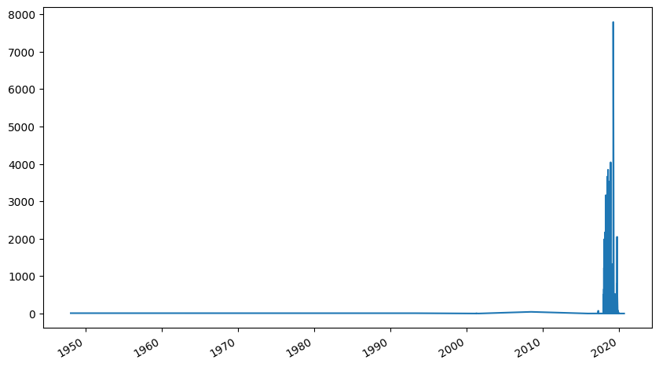

```python
df['timestamp'].value_counts().plot.line(figsize=(10,6))
```

```python
df.loc[df['timestamp'] < '2019-01-01 00:00:00','timestamp' ]
```

```
0         1948-01-26 23:59:00
1         1948-01-26 23:59:00
2         1948-01-26 23:59:00
3         1948-01-26 23:59:00
4         1948-01-26 23:59:00
                  ...
1550781   2018-12-31 23:59:00
1550782   2018-12-31 23:59:00
1550783   2018-12-31 23:59:00
1550784   2018-12-31 23:59:00
1550785   2018-12-31 23:59:00
Name: timestamp, Length: 1550786, dtype: datetime64[ns]
```

```python
df['timestamp'].dt.year.value_counts()
```

```
2018    1550468
2019      45135
2017        223
2008         45
2001         22
1948         10
1993          9
2016          6
2015          3
2020          2
Name: timestamp, dtype: int64
```

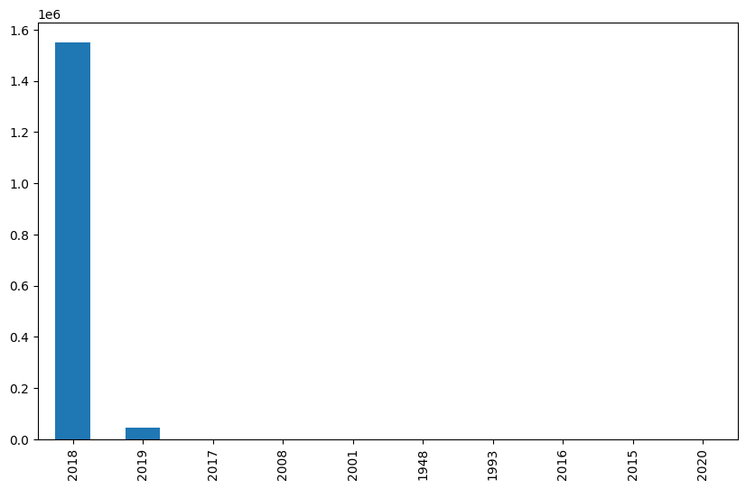

```python
df['timestamp'].dt.year.value_counts().plot.bar(figsize=(10,6))
```

```python
df.loc[df['timestamp'] < '2017-12-30 00:00:00','timestamp']
```

```
0     1948-01-26 23:59:00
1     1948-01-26 23:59:00
2     1948-01-26 23:59:00
3     1948-01-26 23:59:00
4     1948-01-26 23:59:00
              ...
290   2017-12-29 23:59:00
291   2017-12-29 23:59:00
292   2017-12-29 23:59:00
293   2017-12-29 23:59:00
294   2017-12-29 23:59:00
Name: timestamp, Length: 295, dtype: datetime64[ns]
```

```python
df.loc[df['timestamp'] < '2017-12-30 00:00:00','timestamp'].index
```

```
Int64Index([  0,   1,   2,   3,   4,   5,   6,   7,   8,   9,
            ...
            285, 286, 287, 288, 289, 290, 291, 292, 293, 294],
           dtype='int64', length=295)
```

```python
index_time = df.loc[df['timestamp'] < '2017-12-30 00:00:00','timestamp'].index
```

```python
df.loc[index_time]
```

|  | eventID | case Spend area text | case Company | case Document Type | case Sub spend area text | case Purchasing Document | case Purch. Doc. Category name | case Vendor | case Item Type | case Item Category | ... | case GR-Based Inv. Verif. | case Item | case concept:name | case Goods Receipt | event User | event org:resource | event concept:name | event Cumulative net worth (EUR) | event time:timestamp | timestamp |
| --- | --- | --- | --- | --- | --- | --- | --- | --- | --- | --- | --- | --- | --- | --- | --- | --- | --- | --- | --- | --- | --- |
| 0 | 65781719105536 | Sales | companyID_0000 | Standard PO | Products for Resale | 4507004931 | Purchase order | vendorID_0670 | Standard | 3-way match, invoice before GR | ... | False | 20 | 4507004931_00020 | True | NONE | NONE | Vendor creates invoice | 68.0 | 26-01-1948 23:59:00.000 | 1948-01-26 23:59:00 |
| 1 | 65777424138241 | Sales | companyID_0000 | Standard PO | Products for Resale | 4507004931 | Purchase order | vendorID_0670 | Standard | 3-way match, invoice before GR | ... | False | 10 | 4507004931_00010 | True | NONE | NONE | Vendor creates debit memo | 325.0 | 26-01-1948 23:59:00.000 | 1948-01-26 23:59:00 |
| 2 | 65777424138240 | Sales | companyID_0000 | Standard PO | Products for Resale | 4507004931 | Purchase order | vendorID_0670 | Standard | 3-way match, invoice before GR | ... | False | 10 | 4507004931_00010 | True | NONE | NONE | Vendor creates invoice | 325.0 | 26-01-1948 23:59:00.000 | 1948-01-26 23:59:00 |
| 3 | 65794604007424 | Sales | companyID_0000 | Standard PO | Products for Resale | 4507004931 | Purchase order | vendorID_0670 | Standard | 3-way match, invoice before GR | ... | False | 50 | 4507004931_00050 | True | NONE | NONE | Vendor creates invoice | 102.0 | 26-01-1948 23:59:00.000 | 1948-01-26 23:59:00 |
| 4 | 65794604007425 | Sales | companyID_0000 | Standard PO | Products for Resale | 4507004931 | Purchase order | vendorID_0670 | Standard | 3-way match, invoice before GR | ... | False | 50 | 4507004931_00050 | True | NONE | NONE | Vendor creates debit memo | 102.0 | 26-01-1948 23:59:00.000 | 1948-01-26 23:59:00 |
| ... | ... | ... | ... | ... | ... | ... | ... | ... | ... | ... | ... | ... | ... | ... | ... | ... | ... | ... | ... | ... | ... |
| 290 | 9801115369472 | Packaging | companyID_0000 | Standard PO | Labels | 4507000935 | Purchase order | vendorID_0411 | Standard | 3-way match, invoice before GR | ... | False | 70 | 4507000935_00070 | True | NONE | NONE | Vendor creates invoice | 363.0 | 29-12-2017 23:59:00.000 | 2017-12-29 23:59:00 |
| 291 | 12652973654016 | Packaging | companyID_0000 | Standard PO | Labels | 4507001140 | Purchase order | vendorID_0411 | Standard | 3-way match, invoice before GR | ... | False | 20 | 4507001140_00020 | True | NONE | NONE | Vendor creates invoice | 512.0 | 29-12-2017 23:59:00.000 | 2017-12-29 23:59:00 |
| 292 | 4196183048195 | Logistics | companyID_0000 | Framework order | Road Packed | 4507000455 | Purchase order | vendorID_0219 | Service | 3-way match, invoice after GR | ... | True | 10 | 4507000455_00010 | True | NONE | NONE | Vendor creates invoice | 12353.0 | 29-12-2017 23:59:00.000 | 2017-12-29 23:59:00 |
| 293 | 188476049850368 | Marketing | companyID_0000 | EC Purchase order | Digital Marketing | 2000013521 | Purchase order | vendorID_1222 | Service | 3-way match, invoice after GR | ... | True | 1 | 2000013521_00001 | True | NONE | NONE | Vendor creates invoice | 11344.0 | 29-12-2017 23:59:00.000 | 2017-12-29 23:59:00 |
| 294 | 12648678686720 | Packaging | companyID_0000 | Standard PO | Labels | 4507001140 | Purchase order | vendorID_0411 | Standard | 3-way match, invoice before GR | ... | False | 10 | 4507001140_00010 | True | NONE | NONE | Vendor creates invoice | 718.0 | 29-12-2017 23:59:00.000 | 2017-12-29 23:59:00 |

295 rows × 23 columns

```python
new_data01 = df.loc[index_time]
```

```python
new_data01['case concept:name'].unique()
new_data02 = new_data01['case concept:name'].unique()
```

```python
for x in new_data02:
        y = df.loc[df['case concept:name']== x ].index
        print (y)
        df.drop(y,axis=0,inplace=True)
        print('done')
```

[output not shown]

[output cut: 653 more lines]

```
done
Int64Index([290, 3302, 25448, 40632, 53251], dtype='int64')
done
Int64Index([291, 5009, 25450, 35127, 53253], dtype='int64')
done
Int64Index([    293,  330060,  334754,  334755,  334756,  334760,  334761,
             334762,  334764,  334786,  334788,  338782,  364346,  802817,
             803518,  803519,  803520,  803530,  803533,  803534,  803535,
             837475,  837477, 1356650, 1382236, 1382245, 1382246, 1382247,
            1382870, 1384167, 1384168, 1384169, 1384170, 1385905, 1385906,
            1388972, 1409060, 1594032, 1594036],
           dtype='int64')
done
Int64Index([294, 5010, 25453, 35129, 53252], dtype='int64')
done
```

```python
df['timestamp'].dt.year.value_counts()
```

```
2018    1543539
2019      45010
2017         19
2020          2
Name: timestamp, dtype: int64
```

Activity

```python
df.loc[df['case concept:name']=='4508048579_00130']
```

|  | eventID | case Spend area text | case Company | case Document Type | case Sub spend area text | case Purchasing Document | case Purch. Doc. Category name | case Vendor | case Item Type | case Item Category | ... | case GR-Based Inv. Verif. | case Item | case concept:name | case Goods Receipt | event User | event org:resource | event concept:name | event Cumulative net worth (EUR) | event time:timestamp | timestamp |
| --- | --- | --- | --- | --- | --- | --- | --- | --- | --- | --- | --- | --- | --- | --- | --- | --- | --- | --- | --- | --- | --- |
| 928521 | 697502688870400 | Packaging | companyID_0000 | Standard PO | Labels | 4508048579 | Purchase order | vendorID_0120 | Standard | 3-way match, invoice before GR | ... | False | 130 | 4508048579_00130 | True | user_057 | user_057 | Create Purchase Order Item | 418.0 | 10-08-2018 16:20:00.000 | 2018-10-08 16:20:00 |
| 992830 | 697502688870401 | Packaging | companyID_0000 | Standard PO | Labels | 4508048579 | Purchase order | vendorID_0120 | Standard | 3-way match, invoice before GR | ... | False | 130 | 4508048579_00130 | True | user_034 | user_034 | Record Goods Receipt | 418.0 | 29-08-2018 11:17:00.000 | 2018-08-29 11:17:00 |
| 1012540 | 697502688870402 | Packaging | companyID_0000 | Standard PO | Labels | 4508048579 | Purchase order | vendorID_0120 | Standard | 3-way match, invoice before GR | ... | False | 130 | 4508048579_00130 | True | NONE | NONE | Vendor creates invoice | 418.0 | 30-08-2018 23:59:00.000 | 2018-08-30 23:59:00 |
| 1015172 | 697502688870403 | Packaging | companyID_0000 | Standard PO | Labels | 4508048579 | Purchase order | vendorID_0120 | Standard | 3-way match, invoice before GR | ... | False | 130 | 4508048579_00130 | True | user_012 | user_012 | Record Invoice Receipt | 418.0 | 31-08-2018 12:26:00.000 | 2018-08-31 12:26:00 |
| 1505633 | 697502688870404 | Packaging | companyID_0000 | Standard PO | Labels | 4508048579 | Purchase order | vendorID_0120 | Standard | 3-way match, invoice before GR | ... | False | 130 | 4508048579_00130 | True | user_023 | user_023 | Remove Payment Block | 418.0 | 13-12-2018 08:03:00.000 | 2018-12-13 08:03:00 |
| 1507705 | 697502688870405 | Packaging | companyID_0000 | Standard PO | Labels | 4508048579 | Purchase order | vendorID_0120 | Standard | 3-way match, invoice before GR | ... | False | 130 | 4508048579_00130 | True | user_002 | user_002 | Clear Invoice | 418.0 | 13-12-2018 14:08:00.000 | 2018-12-13 14:08:00 |

6 rows × 23 columns

```python
df.loc[df['case concept:name']=='4508048579_00130'].index
```

```
Int64Index([928521, 992830, 1012540, 1015172, 1505633, 1507705], dtype='int64')
```

```python
df['event concept:name'].unique()
```

```
array(['Create Purchase Requisition Item', 'Vendor creates invoice',
       'Create Purchase Order Item', 'Receive Order Confirmation',
       'Change Price', 'Change Quantity', 'Delete Purchase Order Item',
       'SRM: Created', 'Change Approval for Purchase Order',
       'SRM: Change was Transmitted', 'SRM: Document Completed',
       'SRM: Awaiting Approval', 'SRM: Complete',
       'SRM: In Transfer to Execution Syst.', 'SRM: Ordered',
       'Record Service Entry Sheet', 'Record Goods Receipt',
       'Record Invoice Receipt', 'Cancel Goods Receipt',
       'Update Order Confirmation', 'Remove Payment Block',
       'Vendor creates debit memo', 'Change Delivery Indicator',
       'Reactivate Purchase Order Item', 'Change Storage Location',
       'Cancel Invoice Receipt', 'Clear Invoice',
       'Block Purchase Order Item', 'Change Currency',
       'Release Purchase Order', 'Cancel Subsequent Invoice',
       'SRM: Deleted', 'SRM: Transaction Completed',
       'Record Subsequent Invoice', 'SRM: Incomplete', 'SRM: Held',
       'Change payment term', 'Set Payment Block',
       'Change Rejection Indicator', 'Change Final Invoice Indicator',
       'Release Purchase Requisition', 'SRM: Transfer Failed (E.Sys.)'],
      dtype=object)
```

```python
df['event concept:name'].value_counts()
```

```
Record Goods Receipt                   312478
Create Purchase Order Item             251489
Record Invoice Receipt                 227097
Vendor creates invoice                 218872
Clear Invoice                          193696
Record Service Entry Sheet             163563
Remove Payment Block                    57078
Create Purchase Requisition Item        46588
Receive Order Confirmation              32058
Change Quantity                         21439
Change Price                            12373
Delete Purchase Order Item               8875
Change Approval for Purchase Order       7476
Cancel Invoice Receipt                   6950
Vendor creates debit memo                6144
Change Delivery Indicator                3287
Cancel Goods Receipt                     3063
SRM: In Transfer to Execution Syst.      1735
Release Purchase Order                   1610
SRM: Ordered                             1603
SRM: Complete                            1603
SRM: Awaiting Approval                   1603
SRM: Document Completed                  1603
SRM: Created                             1603
SRM: Change was Transmitted              1426
Reactivate Purchase Order Item            543
Block Purchase Order Item                 514
Cancel Subsequent Invoice                 491
Release Purchase Requisition              467
Change Storage Location                   415
Update Order Confirmation                 244
SRM: Deleted                              177
Record Subsequent Invoice                 167
Set Payment Block                         123
SRM: Transfer Failed (E.Sys.)              42
Change Currency                            35
Change Final Invoice Indicator             11
SRM: Transaction Completed                  8
Change payment term                         7
SRM: Held                                   6
SRM: Incomplete                             6
Change Rejection Indicator                  2
Name: event concept:name, dtype: int64
```

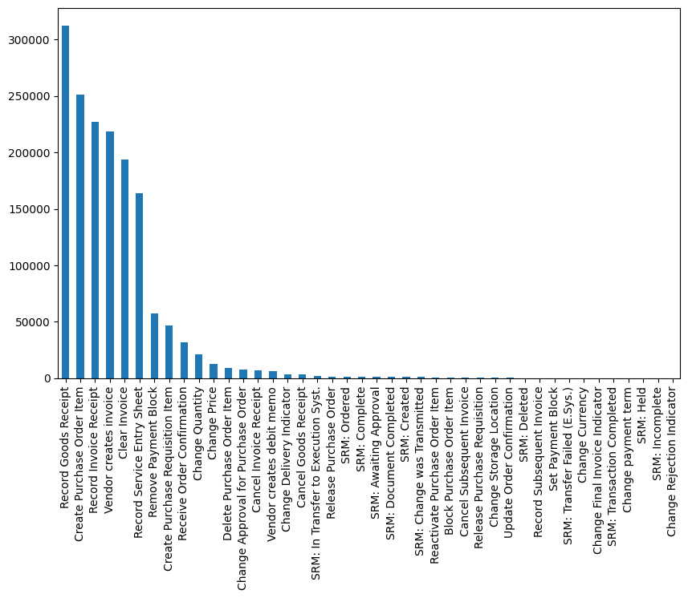

```python
df['event concept:name'].value_counts().plot.bar(figsize=(10,6))
```

Activity_02

```python
df['case Spend area text'].unique()
```

```
array(['Additives', 'Commodity Resins', 'Solvents', 'Logistics',
       'Packaging', 'Enterprise Services', 'Others', 'CAPEX & SOCS',
       'Specialty Resins', 'Sales', 'Trading & End Products',
       'Pigments & Colorants', 'Titanium Dioxides', 'Latex & Monomers',
       nan, 'Marketing', 'Real Estate', 'Spend Area Unidentified',
       'Workforce Services', 'Chemicals & Intermediates', 'Energy'],
      dtype=object)
```

```python
df['case Spend area text'].value_counts()
```

```
Packaging                    583838
Sales                        360323
Logistics                    248407
Trading & End Products       126313
Additives                     95459
CAPEX & SOCS                  39820
Latex & Monomers              26979
Others                        15377
Solvents                      13889
Pigments & Colorants          13811
Specialty Resins              12469
Marketing                     12382
Titanium Dioxides              7453
Enterprise Services            5924
Real Estate                    3710
Workforce Services             3441
Commodity Resins               2374
Spend Area Unidentified         195
Energy                          142
Chemicals & Intermediates         5
Name: case Spend area text, dtype: int64
```

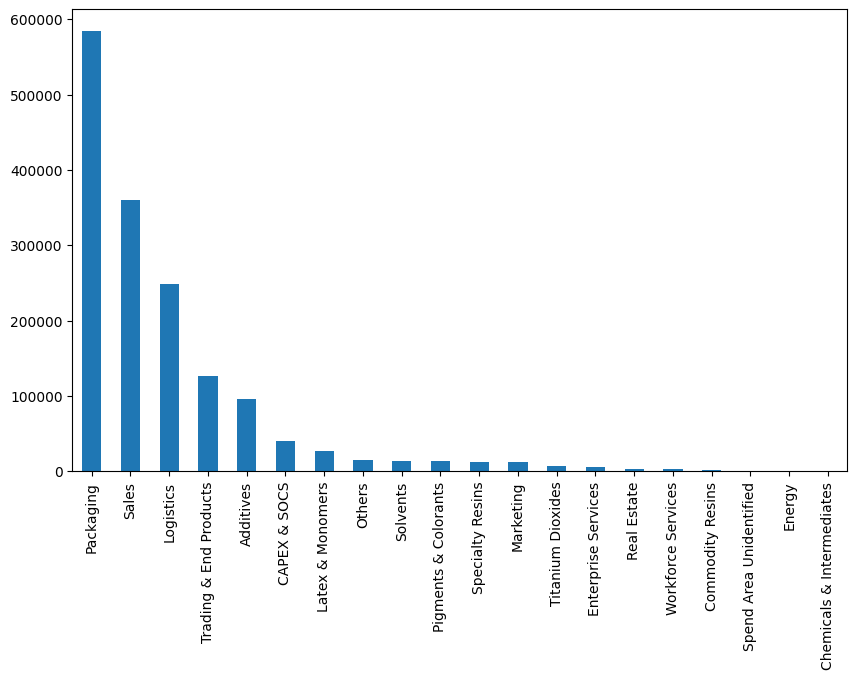

```python
df['case Spend area text'].value_counts().plot.bar(figsize=(10,6))
```

```python
print('====case Spend area text===')
print(df['case Spend area text'].unique())
print('')
```

```
====case Spend area text===
['Additives' 'Commodity Resins' 'Solvents' 'Logistics' 'Packaging'
 'Enterprise Services' 'Others' 'CAPEX & SOCS' 'Specialty Resins' 'Sales'
 'Trading & End Products' 'Pigments & Colorants' 'Titanium Dioxides'
 'Latex & Monomers' nan 'Marketing' 'Real Estate'
 'Spend Area Unidentified' 'Workforce Services'
 'Chemicals & Intermediates' 'Energy']
```

```python
print('====case Company===')
print(df['case Company'].unique())  # no need
print('')
```

```
====case Company===
['companyID_0000' 'companyID_0003' 'companyID_0001' 'companyID_0002']
```

```python
print('====case Document Type===')
print(df['case Document Type'].unique())  # no need
print('')
```

```
====case Document Type===
['Standard PO' 'Framework order' 'EC Purchase order']
```

```python
df.loc[df['case Purchasing Document']== 4508048579]   # need more information
```

|  | eventID | case Spend area text | case Company | case Document Type | case Sub spend area text | case Purchasing Document | case Purch. Doc. Category name | case Vendor | case Item Type | case Item Category | ... | case GR-Based Inv. Verif. | case Item | case concept:name | case Goods Receipt | event User | event org:resource | event concept:name | event Cumulative net worth (EUR) | event time:timestamp | timestamp |
| --- | --- | --- | --- | --- | --- | --- | --- | --- | --- | --- | --- | --- | --- | --- | --- | --- | --- | --- | --- | --- | --- |
| 928521 | 697502688870400 | Packaging | companyID_0000 | Standard PO | Labels | 4508048579 | Purchase order | vendorID_0120 | Standard | 3-way match, invoice before GR | ... | False | 130 | 4508048579_00130 | True | user_057 | user_057 | Create Purchase Order Item | 418.0 | 10-08-2018 16:20:00.000 | 2018-10-08 16:20:00 |
| 928522 | 697506983837696 | Packaging | companyID_0000 | Standard PO | Labels | 4508048579 | Purchase order | vendorID_0120 | Standard | 3-way match, invoice before GR | ... | False | 140 | 4508048579_00140 | True | user_057 | user_057 | Create Purchase Order Item | 529.0 | 10-08-2018 16:20:00.000 | 2018-10-08 16:20:00 |
| 928523 | 697511278804992 | Packaging | companyID_0000 | Standard PO | Labels | 4508048579 | Purchase order | vendorID_0120 | Standard | 3-way match, invoice before GR | ... | False | 150 | 4508048579_00150 | True | user_057 | user_057 | Create Purchase Order Item | 437.0 | 10-08-2018 16:20:00.000 | 2018-10-08 16:20:00 |
| 928524 | 697515573772288 | Packaging | companyID_0000 | Standard PO | Labels | 4508048579 | Purchase order | vendorID_0120 | Standard | 3-way match, invoice before GR | ... | False | 160 | 4508048579_00160 | True | user_057 | user_057 | Create Purchase Order Item | 303.0 | 10-08-2018 16:20:00.000 | 2018-10-08 16:20:00 |
| 928525 | 697519868739584 | Packaging | companyID_0000 | Standard PO | Labels | 4508048579 | Purchase order | vendorID_0120 | Standard | 3-way match, invoice before GR | ... | False | 170 | 4508048579_00170 | True | user_057 | user_057 | Create Purchase Order Item | 303.0 | 10-08-2018 16:20:00.000 | 2018-10-08 16:20:00 |
| ... | ... | ... | ... | ... | ... | ... | ... | ... | ... | ... | ... | ... | ... | ... | ... | ... | ... | ... | ... | ... | ... |
| 1507714 | 697468329132038 | Packaging | companyID_0000 | Standard PO | Labels | 4508048579 | Purchase order | vendorID_0120 | Standard | 3-way match, invoice before GR | ... | False | 50 | 4508048579_00050 | True | user_002 | user_002 | Clear Invoice | 303.0 | 13-12-2018 14:08:00.000 | 2018-12-13 14:08:00 |
| 1507715 | 697464034164741 | Packaging | companyID_0000 | Standard PO | Labels | 4508048579 | Purchase order | vendorID_0120 | Standard | 3-way match, invoice before GR | ... | False | 40 | 4508048579_00040 | True | user_002 | user_002 | Clear Invoice | 401.0 | 13-12-2018 14:08:00.000 | 2018-12-13 14:08:00 |
| 1507716 | 697459739197445 | Packaging | companyID_0000 | Standard PO | Labels | 4508048579 | Purchase order | vendorID_0120 | Standard | 3-way match, invoice before GR | ... | False | 30 | 4508048579_00030 | True | user_002 | user_002 | Clear Invoice | 323.0 | 13-12-2018 14:08:00.000 | 2018-12-13 14:08:00 |
| 1507717 | 697455444230149 | Packaging | companyID_0000 | Standard PO | Labels | 4508048579 | Purchase order | vendorID_0120 | Standard | 3-way match, invoice before GR | ... | False | 20 | 4508048579_00020 | True | user_002 | user_002 | Clear Invoice | 1039.0 | 13-12-2018 14:08:00.000 | 2018-12-13 14:08:00 |
| 1507718 | 697451149262853 | Packaging | companyID_0000 | Standard PO | Labels | 4508048579 | Purchase order | vendorID_0120 | Standard | 3-way match, invoice before GR | ... | False | 10 | 4508048579_00010 | True | user_002 | user_002 | Clear Invoice | 771.0 | 13-12-2018 14:08:00.000 | 2018-12-13 14:08:00 |

151 rows × 23 columns

```python
print('====case Purch. Doc. Category name===')
print(df['case Vendor'].unique())
print('')
```

```
====case Purch. Doc. Category name===
['vendorID_0036' 'vendorID_0317' 'vendorID_0256' ... 'vendorID_1968'
 'vendorID_1973' 'vendorID_1974']
```

```python
df['case Purch. Doc. Category name'].describe()     # no need
```

```
count            1588570
unique                 1
top       Purchase order
freq             1588570
Name: case Purch. Doc. Category name, dtype: object
```

```python
print('====case Vendor===')
print(df['case Vendor'].unique())
print('')
```

```
====case Vendor===
['vendorID_0036' 'vendorID_0317' 'vendorID_0256' ... 'vendorID_1968'
 'vendorID_1973' 'vendorID_1974']
```

```python
df['case Vendor'].describe()
```

```
count           1588570
unique             1966
top       vendorID_0136
freq              79989
Name: case Vendor, dtype: object
```

```python
print('====case Item Type===')
print(df['case Item Type'].unique())
print('')
```

```
====case Item Type===
['Standard' 'Consignment' 'Service' 'Subcontracting' 'Third-party' 'Limit']
```

```python
df['case Item Type'].describe()   #  need more information for relation
```

```
count      1588570
unique           6
top       Standard
freq       1233238
Name: case Item Type, dtype: object
```

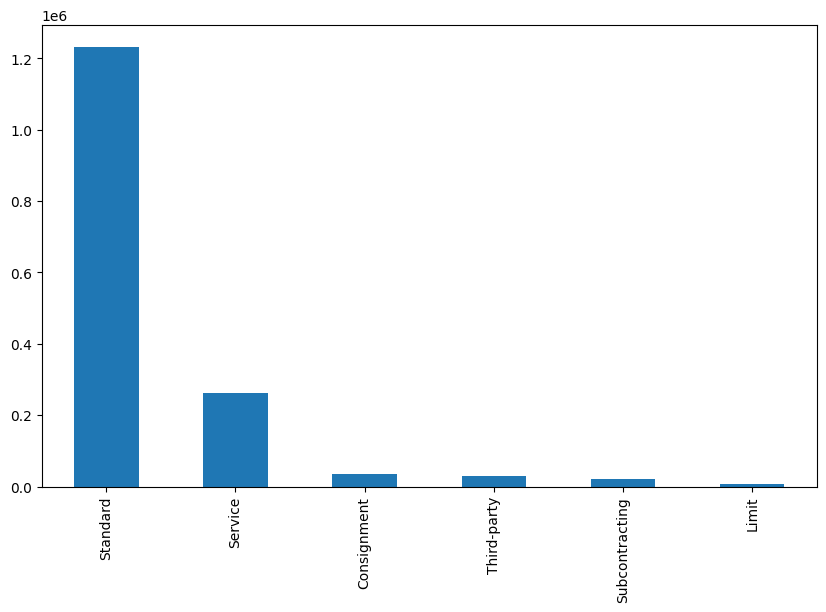

```python
df['case Item Type'].value_counts().plot.bar(figsize=(10,6))            #  need more information for relation
```

```python
print('====case Item Categorye===')
print(df['case Item Category'].unique())
print('')
```

```
====case Item Categorye===
['3-way match, invoice before GR' 'Consignment'
 '3-way match, invoice after GR' '2-way match']
```

```python
df['case Item Category'].describe()     # need more information for relation
```

```
count                            1588570
unique                                 4
top       3-way match, invoice before GR
freq                             1233484
Name: case Item Category, dtype: object
```

```python
print('====case Spend classification text ===')
print(df['case Spend classification text'].unique())
print('')
```

```
====case Spend classification text ===
['PR' 'NPR' 'OTHER' nan]
```

```python
df['case Spend classification text'].describe()
```

```
count     1572311
unique          3
top            PR
freq       882590
Name: case Spend classification text, dtype: object
```

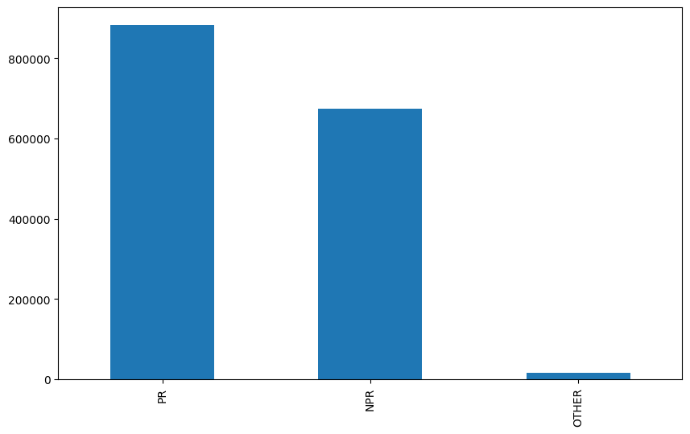

```python
df['case Spend classification text'].value_counts().plot.bar(figsize=(10,6))      # need more information for relation
```

```python
print('====case Source  ===')
print(df['case Source'].unique())
print('')
```

```
====case Source  ===
['sourceSystemID_0000']
```

```python
df['case Source'].describe() # no need
```

```
count                 1588570
unique                      1
top       sourceSystemID_0000
freq                  1588570
Name: case Source, dtype: object
```

```python
print('====case Name  ===')
print(df['case Name'].unique())
print('')
```

```
====case Name  ===
['vendor_0036' 'vendor_0308' 'vendor_0249' ... 'vendor_1892' 'vendor_1897'
 'vendor_1898']
```

```python
df['case Name'].describe()    # need more information
```

```
count         1588570
unique           1890
top       vendor_0135
freq            79989
Name: case Name, dtype: object
```

```python
print('====case GR-Based Inv. Verif.===')
print(df['case GR-Based Inv. Verif.'].unique())
print('')
```

```
====case GR-Based Inv. Verif.===
[False  True]
```

```python
df['case GR-Based Inv. Verif.'].describe()   # need more information
```

```
count     1588570
unique          2
top         False
freq      1275334
Name: case GR-Based Inv. Verif., dtype: object
```

```python
print('====case Item===')
print(df['case Item'].unique())
print('')
```

```
====case Item===
[   10    30    20     1    40    50    80    90    70   100    60   540
   110   120   410   250   260   560   550   270   280   530   290   300
   520   510   310   320   500   490   330   340   480   350   470   360
   460   370   380   450   440   390   400   430   420   130   140   150
   160   170   180   190   200   210   220   580   230   570   240   960
   950   940   930   920   910   900   890   880   870   860   850   840
   830   820   810   800   790   780   770   760   750   740   730   720
   710   700   690   680   670   660   650   640   630   620   610   600
   590     2     3  1060  1050  1040  1030  1020  1010  1000   990   980
   970     4  1070  1080  1090  1100  1110  1120  2070  2240  2230  1200
  2220  1210  1220  1230  1240  1250  1260  1270  1280  1290  2210  1300
  2200  1310  1320  1330  1340  1350  1360  1370  1380  1390  1400  1410
  1420  1430  1440  1450  1460  1470  1480  1490  1500  1510  1520  1530
  1540  1550  1560  2190  1570  1580  1590  2180  1600  1610  2170  2160
```

[output cut: 27 more lines]

```python
df['case Item'].describe()
```

```
count    1.588570e+06
mean     9.088544e+01
std      7.438764e+02
min      1.000000e+00
25%      1.000000e+01
50%      3.000000e+01
75%      9.000000e+01
max      5.355700e+04
Name: case Item, dtype: float64
```

```python
df['event User'].describe()   # need more information
```

```
count     1588570
unique        627
top          NONE
freq       396513
Name: event User, dtype: object
```

```python
print('====event org:resource ===')
print(df['event org:resource'].unique())
print('')
```

```
====event org:resource ===
['user_124' 'NONE' 'batch_03' 'batch_08' 'batch_04' 'user_033' 'user_036'
 'user_038' 'batch_00' 'user_043' 'user_045' 'user_051' 'user_029'
 'user_052' 'user_054' 'user_057' 'user_059' 'user_060' 'user_064'
 'user_066' 'user_068' 'user_070' 'user_072' 'user_075' 'user_079'
 'user_084' 'user_085' 'user_081' 'user_089' 'user_091' 'user_092'
 'user_095' 'user_097' 'user_100' 'user_103' 'user_105' 'user_108'
 'user_000' 'user_116' 'batch_06' 'batch_02' 'user_154' 'user_086'
 'user_113' 'user_119' 'user_122' 'user_121' 'user_128' 'user_129'
 'user_134' 'user_055' 'user_135' 'user_136' 'user_004' 'user_138'
 'user_141' 'user_142' 'user_030' 'user_148' 'user_603' 'user_151'
 'user_153' 'user_156' 'batch_10' 'user_131' 'batch_11' 'user_159'
 'user_080' 'user_160' 'user_163' 'user_164' 'user_167' 'user_024'
 'user_171' 'user_172' 'user_063' 'user_078' 'batch_12' 'user_001'
 'user_056' 'user_177' 'user_168' 'user_098' 'user_602' 'user_157'
 'user_180' 'user_007' 'user_176' 'user_109' 'user_120' 'user_047'
 'user_050' 'user_012' 'user_187' 'batch_13' 'user_006' 'user_191'
 'batch_07' 'user_149' 'user_193' 'user_133' 'user_049' 'user_062'
 'user_008' 'user_139' 'user_034' 'user_194' 'user_039' 'user_200'
 'user_096' 'user_201' 'user_099' 'user_088' 'user_208' 'user_040'
 'user_106' 'user_046' 'user_207' 'user_209' 'user_048' 'user_204'
 'user_210' 'user_206' 'user_130' 'user_104' 'user_213' 'user_214'
 'user_053' 'user_216' 'user_044' 'user_147' 'user_192' 'batch_05'
 'user_077' 'user_090' 'user_127' 'user_087' 'user_218' 'user_042'
 'user_179' 'user_094' 'user_143' 'user_215' 'user_158' 'user_018'
 'user_102' 'user_150' 'user_225' 'user_223' 'user_041' 'user_184'
 'user_227' 'user_229' 'user_231' 'user_236' 'user_144' 'user_185'
 'user_110' 'user_238' 'user_067' 'user_239' 'user_069' 'user_240'
 'user_093' 'user_031' 'user_107' 'user_074' 'user_183' 'user_359'
 'user_244' 'user_101' 'user_152' 'user_137' 'user_249' 'user_188'
 'user_146' 'user_145' 'user_117' 'user_252' 'user_256' 'user_230'
 'user_155' 'user_212' 'user_203' 'user_174' 'user_071' 'user_035'
 'user_202' 'user_241' 'user_011' 'user_140' 'user_126' 'user_076'
 'user_058' 'user_032' 'user_246' 'user_266' 'user_217' 'user_199'
 'user_162' 'user_271' 'user_274' 'user_263' 'user_245' 'user_061'
 'user_169' 'user_243' 'user_082' 'user_065' 'user_175' 'user_198'
 'user_276' 'user_182' 'user_233' 'user_277' 'batch_09' 'user_247'
 'user_220' 'user_278' 'user_260' 'user_123' 'user_267' 'user_279'
 'user_173' 'user_242' 'user_280' 'user_232' 'user_161' 'user_219'
 'user_281' 'user_264' 'user_234' 'user_284' 'user_211' 'user_268'
```

[output cut: 51 more lines]

```
 'user_537' 'user_539' 'user_540' 'user_534' 'user_538' 'user_546'
 'user_545' 'user_541' 'user_325' 'user_550' 'user_558' 'user_559'
 'user_548' 'user_552' 'user_551' 'user_420' 'user_428' 'user_606'
 'user_553' 'user_554' 'user_549' 'user_555' 'user_556' 'user_557'
 'batch_19' 'user_400' 'user_424' 'user_560' 'user_565' 'user_564'
 'user_563' 'user_567' 'user_562' 'user_566' 'user_568' 'user_561'
 'user_571' 'user_570' 'user_572' 'user_573' 'user_396' 'user_577'
 'user_291' 'user_578' 'user_579' 'user_411' 'user_576' 'user_397'
 'user_580' 'user_443' 'user_438' 'user_583' 'user_584' 'user_582'
 'user_390' 'user_585' 'user_575' 'user_586' 'user_574' 'user_588'
 'user_569' 'user_589' 'user_590' 'user_591' 'user_581' 'user_593'
 'user_594' 'user_595' 'user_445' 'user_587' 'user_597' 'user_598'
 'user_592' 'user_381' 'user_017' 'user_419' 'batch_18' 'user_021'
 'user_489' 'user_073' 'user_444' 'user_601' 'user_596' 'user_599'
 'user_600' 'user_003']
```

```python
df['event org:resource'].describe()    # same as before -  no need
```

```
count     1588570
unique        627
top          NONE
freq       396513
Name: event org:resource, dtype: object
```

```python
print('====event Cumulative net worth (EUR) ===')
print(df['event Cumulative net worth (EUR)'].unique())
print('')
```

```
====event Cumulative net worth (EUR) ===
[  3732.   2546.      0. ...  71719. 126786.  22719.]
```

```python
df['event Cumulative net worth (EUR)'].describe()  # need more information
```

```
count    1.588570e+06
mean     1.244667e+04
std      1.547815e+05
min      0.000000e+00
25%      1.440000e+02
50%      5.360000e+02
75%      2.430000e+03
max      2.899453e+07
Name: event Cumulative net worth (EUR), dtype: float64
```

Event ID

```python
df['eventID '].unique()
```

```
array([   6665789243392,    6575594930176,    5347234283520, ...,
       1009441868611588,  273679611068428,   77635828842576], dtype=int64)
```

```python
pd.value_counts(df['eventID '])
```

```
6665789243392      1
784450006810624    1
727219567591436    1
766308064952323    1
668533134458881    1
                  ..
393565033201666    1
422564652384259    1
238559663489079    1
238559663489078    1
77635828842576     1
Name: eventID , Length: 1588570, dtype: int64
```

```python
count = df['eventID '].value_counts()
(count == 1).value_counts()
```

```
True    1588570
Name: eventID , dtype: int64
```

eventID can not be a case ID in Disco

```python
df.loc[df['eventID ']== 697502688870404,:]
```

|  | eventID | case Spend area text | case Company | case Document Type | case Sub spend area text | case Purchasing Document | case Purch. Doc. Category name | case Vendor | case Item Type | case Item Category | ... | case GR-Based Inv. Verif. | case Item | case concept:name | case Goods Receipt | event User | event org:resource | event concept:name | event Cumulative net worth (EUR) | event time:timestamp | timestamp |
| --- | --- | --- | --- | --- | --- | --- | --- | --- | --- | --- | --- | --- | --- | --- | --- | --- | --- | --- | --- | --- | --- |
| 1505633 | 697502688870404 | Packaging | companyID_0000 | Standard PO | Labels | 4508048579 | Purchase order | vendorID_0120 | Standard | 3-way match, invoice before GR | ... | False | 130 | 4508048579_00130 | True | user_023 | user_023 | Remove Payment Block | 418.0 | 13-12-2018 08:03:00.000 | 2018-12-13 08:03:00 |

1 rows × 23 columns

```python
df.loc[df['case Purchasing Document']== 4508048579,:]
```

|  | eventID | case Spend area text | case Company | case Document Type | case Sub spend area text | case Purchasing Document | case Purch. Doc. Category name | case Vendor | case Item Type | case Item Category | ... | case GR-Based Inv. Verif. | case Item | case concept:name | case Goods Receipt | event User | event org:resource | event concept:name | event Cumulative net worth (EUR) | event time:timestamp | timestamp |
| --- | --- | --- | --- | --- | --- | --- | --- | --- | --- | --- | --- | --- | --- | --- | --- | --- | --- | --- | --- | --- | --- |
| 928521 | 697502688870400 | Packaging | companyID_0000 | Standard PO | Labels | 4508048579 | Purchase order | vendorID_0120 | Standard | 3-way match, invoice before GR | ... | False | 130 | 4508048579_00130 | True | user_057 | user_057 | Create Purchase Order Item | 418.0 | 10-08-2018 16:20:00.000 | 2018-10-08 16:20:00 |
| 928522 | 697506983837696 | Packaging | companyID_0000 | Standard PO | Labels | 4508048579 | Purchase order | vendorID_0120 | Standard | 3-way match, invoice before GR | ... | False | 140 | 4508048579_00140 | True | user_057 | user_057 | Create Purchase Order Item | 529.0 | 10-08-2018 16:20:00.000 | 2018-10-08 16:20:00 |
| 928523 | 697511278804992 | Packaging | companyID_0000 | Standard PO | Labels | 4508048579 | Purchase order | vendorID_0120 | Standard | 3-way match, invoice before GR | ... | False | 150 | 4508048579_00150 | True | user_057 | user_057 | Create Purchase Order Item | 437.0 | 10-08-2018 16:20:00.000 | 2018-10-08 16:20:00 |
| 928524 | 697515573772288 | Packaging | companyID_0000 | Standard PO | Labels | 4508048579 | Purchase order | vendorID_0120 | Standard | 3-way match, invoice before GR | ... | False | 160 | 4508048579_00160 | True | user_057 | user_057 | Create Purchase Order Item | 303.0 | 10-08-2018 16:20:00.000 | 2018-10-08 16:20:00 |
| 928525 | 697519868739584 | Packaging | companyID_0000 | Standard PO | Labels | 4508048579 | Purchase order | vendorID_0120 | Standard | 3-way match, invoice before GR | ... | False | 170 | 4508048579_00170 | True | user_057 | user_057 | Create Purchase Order Item | 303.0 | 10-08-2018 16:20:00.000 | 2018-10-08 16:20:00 |
| ... | ... | ... | ... | ... | ... | ... | ... | ... | ... | ... | ... | ... | ... | ... | ... | ... | ... | ... | ... | ... | ... |
| 1507714 | 697468329132038 | Packaging | companyID_0000 | Standard PO | Labels | 4508048579 | Purchase order | vendorID_0120 | Standard | 3-way match, invoice before GR | ... | False | 50 | 4508048579_00050 | True | user_002 | user_002 | Clear Invoice | 303.0 | 13-12-2018 14:08:00.000 | 2018-12-13 14:08:00 |
| 1507715 | 697464034164741 | Packaging | companyID_0000 | Standard PO | Labels | 4508048579 | Purchase order | vendorID_0120 | Standard | 3-way match, invoice before GR | ... | False | 40 | 4508048579_00040 | True | user_002 | user_002 | Clear Invoice | 401.0 | 13-12-2018 14:08:00.000 | 2018-12-13 14:08:00 |
| 1507716 | 697459739197445 | Packaging | companyID_0000 | Standard PO | Labels | 4508048579 | Purchase order | vendorID_0120 | Standard | 3-way match, invoice before GR | ... | False | 30 | 4508048579_00030 | True | user_002 | user_002 | Clear Invoice | 323.0 | 13-12-2018 14:08:00.000 | 2018-12-13 14:08:00 |
| 1507717 | 697455444230149 | Packaging | companyID_0000 | Standard PO | Labels | 4508048579 | Purchase order | vendorID_0120 | Standard | 3-way match, invoice before GR | ... | False | 20 | 4508048579_00020 | True | user_002 | user_002 | Clear Invoice | 1039.0 | 13-12-2018 14:08:00.000 | 2018-12-13 14:08:00 |
| 1507718 | 697451149262853 | Packaging | companyID_0000 | Standard PO | Labels | 4508048579 | Purchase order | vendorID_0120 | Standard | 3-way match, invoice before GR | ... | False | 10 | 4508048579_00010 | True | user_002 | user_002 | Clear Invoice | 771.0 | 13-12-2018 14:08:00.000 | 2018-12-13 14:08:00 |

151 rows × 23 columns

```python
df.loc[df['case concept:name']=='4508048579_00130']
```

|  | eventID | case Spend area text | case Company | case Document Type | case Sub spend area text | case Purchasing Document | case Purch. Doc. Category name | case Vendor | case Item Type | case Item Category | ... | case GR-Based Inv. Verif. | case Item | case concept:name | case Goods Receipt | event User | event org:resource | event concept:name | event Cumulative net worth (EUR) | event time:timestamp | timestamp |
| --- | --- | --- | --- | --- | --- | --- | --- | --- | --- | --- | --- | --- | --- | --- | --- | --- | --- | --- | --- | --- | --- |
| 928521 | 697502688870400 | Packaging | companyID_0000 | Standard PO | Labels | 4508048579 | Purchase order | vendorID_0120 | Standard | 3-way match, invoice before GR | ... | False | 130 | 4508048579_00130 | True | user_057 | user_057 | Create Purchase Order Item | 418.0 | 10-08-2018 16:20:00.000 | 2018-10-08 16:20:00 |
| 992830 | 697502688870401 | Packaging | companyID_0000 | Standard PO | Labels | 4508048579 | Purchase order | vendorID_0120 | Standard | 3-way match, invoice before GR | ... | False | 130 | 4508048579_00130 | True | user_034 | user_034 | Record Goods Receipt | 418.0 | 29-08-2018 11:17:00.000 | 2018-08-29 11:17:00 |
| 1012540 | 697502688870402 | Packaging | companyID_0000 | Standard PO | Labels | 4508048579 | Purchase order | vendorID_0120 | Standard | 3-way match, invoice before GR | ... | False | 130 | 4508048579_00130 | True | NONE | NONE | Vendor creates invoice | 418.0 | 30-08-2018 23:59:00.000 | 2018-08-30 23:59:00 |
| 1015172 | 697502688870403 | Packaging | companyID_0000 | Standard PO | Labels | 4508048579 | Purchase order | vendorID_0120 | Standard | 3-way match, invoice before GR | ... | False | 130 | 4508048579_00130 | True | user_012 | user_012 | Record Invoice Receipt | 418.0 | 31-08-2018 12:26:00.000 | 2018-08-31 12:26:00 |
| 1505633 | 697502688870404 | Packaging | companyID_0000 | Standard PO | Labels | 4508048579 | Purchase order | vendorID_0120 | Standard | 3-way match, invoice before GR | ... | False | 130 | 4508048579_00130 | True | user_023 | user_023 | Remove Payment Block | 418.0 | 13-12-2018 08:03:00.000 | 2018-12-13 08:03:00 |
| 1507705 | 697502688870405 | Packaging | companyID_0000 | Standard PO | Labels | 4508048579 | Purchase order | vendorID_0120 | Standard | 3-way match, invoice before GR | ... | False | 130 | 4508048579_00130 | True | user_002 | user_002 | Clear Invoice | 418.0 | 13-12-2018 14:08:00.000 | 2018-12-13 14:08:00 |

6 rows × 23 columns

```python
df['case concept:name'].describe()
```

```
count              1588570
unique              251489
top       4507004396_00020
freq                   868
Name: case concept:name, dtype: object
```

```python
string_case_name = (df['case concept:name']).str.len()
(string_case_name == 16).value_counts()
```

```
True    1588570
Name: case concept:name, dtype: int64
```

```python
df['case concept:name'].head(5)
```

```
295    4507000681_00010
296    4507000667_00010
297    4507000542_00030
298    4507000703_00010
299    4507007815_00010
Name: case concept:name, dtype: object
```

```python
df['case concept:name'].isnull().sum()
```

```
0
```

```python
case_id = df['case concept:name'].replace('_', '', regex=True)
```

```python
df['case concept:name'] = case_id
```

```python
df['case concept:name']
```

```
295        450700068100010
296        450700066700010
297        450700054200030
298        450700070300010
299        450700781500010
                ...
1595918    450805580800020
1595919    450807128100010
1595920    450807128100140
1595921    450701932200010
1595922    450700574400010
Name: case concept:name, Length: 1588570, dtype: object
```

```python
df['case concept:name'] = pd.to_numeric(df['case concept:name']) # convert case_ID
```

Attribute

```python
df['case Spend area text'].unique()
```

```
array(['Additives', 'Commodity Resins', 'Solvents', 'Logistics',
       'Packaging', 'Enterprise Services', 'Others', 'CAPEX & SOCS',
       'Specialty Resins', 'Sales', 'Trading & End Products',
       'Pigments & Colorants', 'Titanium Dioxides', 'Latex & Monomers',
       nan, 'Marketing', 'Real Estate', 'Spend Area Unidentified',
       'Workforce Services', 'Chemicals & Intermediates', 'Energy'],
      dtype=object)
```

```python
df['case Sub spend area text'].unique()
```

```
array(['Waxes', 'Commodity Resins Precursors', 'Aliphatic Solvents',
       'Glycol & Ether Solvents', 'Road Packed', 'Pallets',
       'Other Logistics Services', 'Sea', 'ICT Services', 'Packaging',
       'Technical Services', 'Labels', 'Extenders',
       'Plastic Containers & Lids < 30L', 'Metal Containers & Lids < 30L',
       'Alkyd Resins', 'Products for Resale', 'Color Collateral',
       'Defoamers & Antifoams', 'Surfactants',
       'Driers & Antiskinning Agents', 'Trading products (old structure)',
       'Laboratory Supplies & Services', 'Mixing Machines',
       'Plastic Film', 'Biocides', 'Colorants', 'Chloride',
       'Ester Solvents', 'Customers', 'Opaque Polymers', 'Closures',
       'Light & Heat Stabilizers', nan, 'Rheology & Thixotropic Agents',
       'Plasticizers', 'Pure Acrylics', 'Styrene Acrylics',
       'Carbon Black Pigments', 'Facility Management',
       'Neutralisation Agents', 'Vinyl Acetate Ethylenes',
       'Vinyl Acrylics', 'Drums', 'Aromatic Solvents',
       'Specialty Resins - Other', 'Inorganic Pigments',
       'Organic Pigments', 'MRO (components)', 'Alcohol Solvents',
       'Corrosion Inhibitors', 'Isocyanates', 'Catalysts & Initiators',
       'Jerry Cans', 'Specialty Resins Precursors',
       'Business Gifts & Promotional Items', 'Polyester Resins - Liquid',
       'Monomers - Styrene', 'Fire Protection Agents', 'Warehousing',
       'Marketing Support Services', 'Packaging - Other',
       'Additives - Other', 'Utilities', 'Sulphate', 'Ketones Solvents',
       'Acrylic Resins – Liquid', 'Paperboard', 'Epoxy Resins - Liquid',
       'Tubes', 'Latexes - Other', 'UV Resins',
       'Real estate brokers or agents', 'Bags', 'Equipment',
       'Intermediate Bulk Containers (IBC)', 'Polyurethane Resins',
       'Digital Marketing', 'Polyamides & Polyamines', 'Business park',
       'Effect Pigments', 'Process Automation & Instrumentation',
       'Polyvinyl Acetates', 'Spend Area Unidentified', 'Cartridges',
       'Third Party Labor', 'Office Supplies', 'Commercial Printing',
       'HR Services', 'Raw Material', 'Advertising', 'ICT Software',
       'Bottles', 'Amino Resins', 'Caseins & Starches',
       'Adhesion Promotors', 'Point of Sales', 'Express',
       'Catalysts (C&I)', 'Hybrid Containers', 'Sachets', 'Design',
       'Transport & Hoisting Equipment', 'Consulting', 'Sales Promotion',
       'Gasses', 'ICT Hardware', 'Epoxy Resins - Solid', 'Communications',
       'Exhibitions & seminars', 'Travel & expenses',
       'Spectrophotometers', 'Public Relations', 'Solvents - Other',
       'Market Research', 'Transport Intersite',
       'Semi-Finished Materials', 'Escrow and title services',
       'Real Estate - To Be Approved', 'Real estate services',
       'QHSE Services', 'Government payments',
       'LOGISTICS - TO BE APPROVED', 'Insurances', 'Electricity',
       'Marketing - To Be Approved', 'Others - TBH',
       'Information Services', 'Taxation', 'Pigments - Other',
       'Monomers - Hydroxy', 'Polyvinyl Alcohols', 'Media',
       'SOC&S - Other', 'Legal', 'Employee-related payments and pensions'],
      dtype=object)
```

Delete unnecessary column

```python
df.reset_index(drop=True, inplace=True)
```

```python
columns = ['eventID ','case Company','case Document Type','case Purch. Doc. Category name','case Source','case Goods Receipt','event org:resource','event time:timestamp','case Purchasing Document','case Item','case Item Type','case Spend classification text','event Cumulative net worth (EUR)']
columns
```

```
['eventID ',
 'case Company',
 'case Document Type',
 'case Purch. Doc. Category name',
 'case Source',
 'case Goods Receipt',
 'event org:resource',
 'event time:timestamp',
 'case Purchasing Document',
 'case Item',
 'case Item Type',
 'case Spend classification text',
 'event Cumulative net worth (EUR)']
```

```python
df = df.drop(columns, axis=1)
```

```python
df.head()
```

|  | case Spend area text | case Sub spend area text | case Vendor | case Item Category | case Name | case GR-Based Inv. Verif. | case concept:name | event User | event concept:name | timestamp |
| --- | --- | --- | --- | --- | --- | --- | --- | --- | --- | --- |
| 0 | Additives | Waxes | vendorID_0036 | 3-way match, invoice before GR | vendor_0036 | False | 450700068100010 | user_124 | Create Purchase Requisition Item | 2017-12-31 00:00:00 |
| 1 | Commodity Resins | Commodity Resins Precursors | vendorID_0317 | 3-way match, invoice before GR | vendor_0308 | False | 450700066700010 | user_124 | Create Purchase Requisition Item | 2017-12-31 00:00:00 |
| 2 | Solvents | Aliphatic Solvents | vendorID_0256 | Consignment | vendor_0249 | False | 450700054200030 | user_124 | Create Purchase Requisition Item | 2017-12-31 00:00:00 |
| 3 | Solvents | Glycol & Ether Solvents | vendorID_0198 | 3-way match, invoice before GR | vendor_0195 | False | 450700070300010 | user_124 | Create Purchase Requisition Item | 2017-12-31 00:00:00 |
| 4 | Logistics | Road Packed | vendorID_0364 | 3-way match, invoice after GR | vendor_0353 | True | 450700781500010 | NONE | Vendor creates invoice | 2017-12-31 23:59:00 |

```python
df.info()
```

```
<class 'pandas.core.frame.DataFrame'>
RangeIndex: 1588570 entries, 0 to 1588569
Data columns (total 10 columns):
 #   Column                     Non-Null Count    Dtype
---  ------                     --------------    -----
 0   case Spend area text       1572311 non-null  object
 1   case Sub spend area text   1572311 non-null  object
 2   case Vendor                1588570 non-null  object
 3   case Item Category         1588570 non-null  object
 4   case Name                  1588570 non-null  object
 5   case GR-Based Inv. Verif.  1588570 non-null  bool
 6   case concept:name          1588570 non-null  int64
 7   event User                 1588570 non-null  object
 8   event concept:name         1588570 non-null  object
 9   timestamp                  1588570 non-null  datetime64[ns]
dtypes: bool(1), datetime64[ns](1), int64(1), object(7)
memory usage: 110.6+ MB
```

Final data set

```python
df.to_csv('Final_desco.csv', encoding='utf-8', index=False)
```

# Disco Output

```python
# Image display
from IPython.display import Image
from IPython.core.display import HTML
```

```python
Image(url= "Image/Disco_banner.png")
```

[figure not shown]

```python
Image(url= "Image/Disco_final.png")
```

[figure not shown]